# Problema 1 - Checkpoint 3 - Sua análise

Thierry Barros

April 25, 2018

```r
episodes = read_csv(here("data/series_from_imdb.csv"),
                    progress = FALSE,
                    col_types = cols(.default = col_double(),
                                     series_name = col_character(),
                                     episode = col_character(),
                                     url = col_character(),
                                     season = col_character()))
seriesLongas = group_by(episodes,series_name) %>% summarise(NTemporadas=n_distinct(season)) %>% arrange(desc(NTemporadas))
top40 = head(seriesLongas, n=40)
series8temporadas = top40 %>% filter(NTemporadas==8)
```

# 1. Séries com muitas temporadas mantém a qualidade nas avaliações?

Para analisar e responder essa questão selecionei 10 séries com 8 temporadas. Fizemos um gráfico para ver a variação da média de avalição dos usuários no decorrer das temporadas.

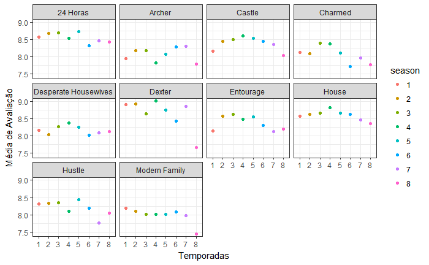

```r
series8temporadas = episodes %>% filter(series_name %in% series8temporadas$series_name )
avaliacao = group_by(series8temporadas,series_name,season) %>% summarise(Total=mean(user_rating)) %>% arrange(desc(season))
avaliacao %>%  ggplot(aes(x = season, y = Total, color = season)) +
  geom_point() +
  facet_wrap(~ series_name)+ xlab("Temporadas") +
  ylab("Média de Avaliação")
```

```r
avaliacaoDesvio = group_by(series8temporadas,series_name) %>% summarise(Desvio=sd(user_rating))
avaliacaoDesvio[order(avaliacaoDesvio$Desvio),]
```

| series_name | Desvio |
| --- | --- |
| 24 Horas | 0.2922363 |
| Desperate Housewives | 0.3116300 |
| Archer | 0.3398511 |
| Hustle | 0.3642733 |
| Entourage | 0.3646541 |
| House | 0.3893251 |
| Modern Family | 0.4090622 |
| Castle | 0.4372739 |
| Charmed | 0.5221219 |
| Dexter | 0.6126723 |

Olhando podemos ver que em geral as séries tem um inicio mediano, tendem a melhorar até a metade da temporadas e tem um decaída pro final. Mas a variação das médias de notas por temporadas não é muito grande fica em torno de 0.5 pontos para mais ou menos.

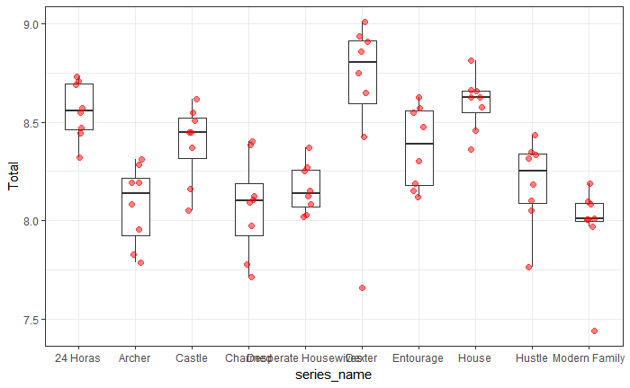

```r
avaliacao %>%
    ggplot(aes(x = series_name, y = Total)) +
    geom_boxplot(width = .5, outlier.color = NA) +
    geom_jitter(width = .1, size = 2, alpha = .5, color = "red")
```

Outra maneira de vizualizar esses dados é utilizando box_plot para notar a dispersão das notas por temporadas, a variação em geral não passar de 1 ponto de diferença, reforçando a hipótese de que séreis grandes mantém a qualidade.

# Essa próxima análise foi só para checar se existe alguma relação entre o número de votos e o média de avalição nas séries. E também se tem relação entre o número de episódios e a popularidade da série.

```r
seriesMaisVotadas = group_by(episodes,series_name) %>% summarise(Media = mean(user_rating),NVotos=sum(user_votes)) %>% arrange(desc(Media))
cor(seriesMaisVotadas$Media,seriesMaisVotadas$NVotos)
```

```
[1] 0.2499489
```

```r
seriesLongasEP = group_by(episodes,series_name) %>% summarise(NEpisodios=n(),Popularidade = sum(user_votes)) %>% arrange(desc(NEpisodios))
cor(seriesLongasEP$NEpisodios,seriesLongasEP$Popularidade)
```

```
[1] 0.3365424
```

O valores de correlação pra os dois casos foram pequenos, mostrando assim que a relação é fraca.

# 2. Como se comporta o número de votos por episódio ao decorrer das temporadas?

Isso é pra avaliar se a populariade da série aumenta com o decorrer das temporadas. Para responder essa questão eu utilizei os dados da série Sobrenatural que tem 12 temporadas.

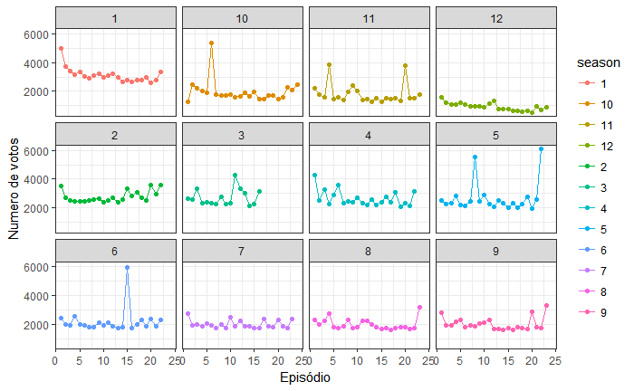

```r
supernatural = episodes %>% filter(series_name == "Supernatural" )
supernatural %>%  ggplot(aes(x = season_ep, y = user_votes, color = season)) +
  geom_line() +
  geom_point() +
  facet_wrap(~ season)+ xlab("Episódio") +
  ylab("Numero de votos")
```

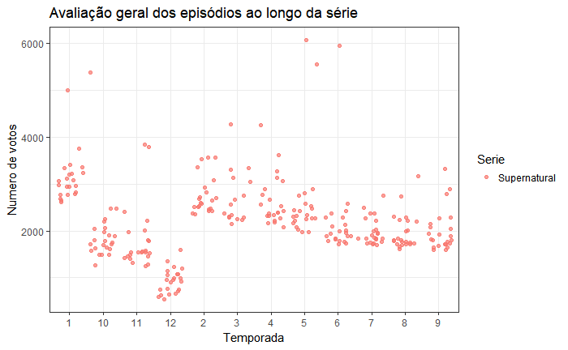

```r
supernatural %>%
    mutate (Serie = series_name) %>%
    ggplot(aes(x = season,
               y = user_votes,
               color = Serie)) +
    geom_jitter(alpha = 0.7) +
    xlab("Temporada") +
    ylab("Numero de votos") +
    ggtitle("Avaliação geral dos episódios ao longo da série")
```

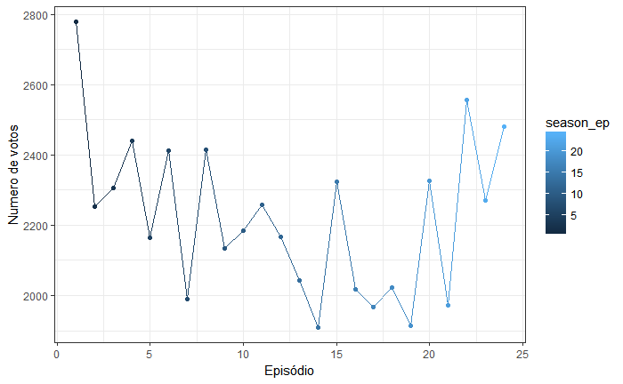

```r
votosPorTemporada = group_by(supernatural,season_ep) %>% summarise(Media = (sum(user_votes)/n())) %>% arrange(desc(Media))
votosPorTemporada %>%  ggplot(aes(x = season_ep, y = Media, color = season_ep)) +
  geom_line() +
  geom_point() +
 xlab("Episódio") +
  ylab("Numero de votos")
```

Outra análise que podemos fazer é por episódio em cada temporada, se o primeiro episódio é mais popular que o segundo, e segundo que o terceiro e assim por diante em geral. Podemo ver que o primeiro épisódio em geral é mais popular doque o resto,mas em geral os episódio mantem uma proximidade no numero de votos.Podemos notar que o número do episódio não influencia muito em sua popularidade, exceto pelo primeiro que o último.

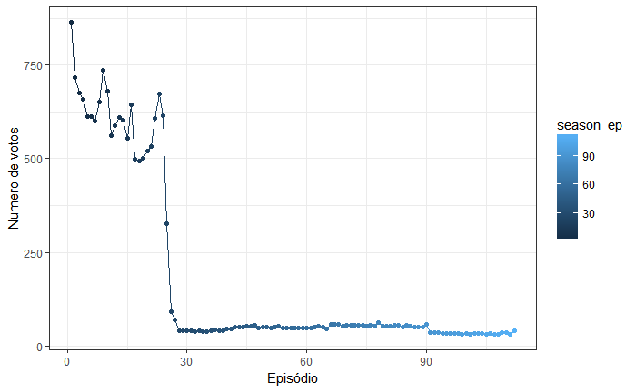

```r
votosPorTemporada = group_by(episodes,season_ep) %>% summarise(Media = (sum(user_votes)/n())) %>% arrange(desc(Media))
votosPorTemporada %>%  ggplot(aes(x = season_ep, y = Media, color = season_ep)) +
  geom_line() +
  geom_point() +

 xlab("Episódio") +
  ylab("Numero de votos")
```

# As melhores séries são maiores que a piores?

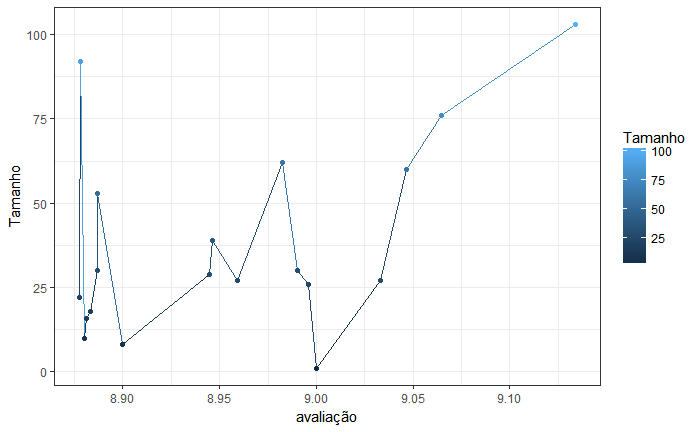

```r
melhores_series = group_by(episodes,series_name) %>% summarise(Tamanho = n(),avaliação = mean(user_rating)) %>% arrange(desc(avaliação))
melhores = head(melhores_series,20)
piores = tail(melhores_series,20)
melhores %>%  ggplot(aes(x = avaliação, y = Tamanho, color=Tamanho)) +
  geom_line() +
  geom_point()
```

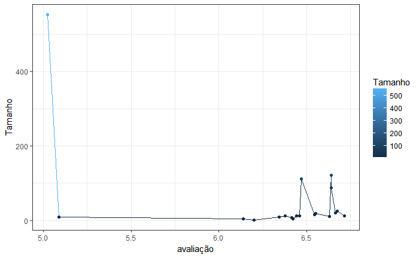

```r
piores %>%  ggplot(aes(x = avaliação, y = Tamanho, color=Tamanho)) +
  geom_line() +
  geom_point()
```

# O tamanho da temporada influencia na avaliação?

Para responder essa questão foram pegos as 15 maiores e menores temporadas.

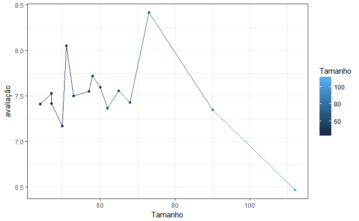

```r
maioresTemporadas = group_by(episodes,series_name,season) %>% summarise(Tamanho = n(),avaliação = mean(user_rating)) %>% arrange(desc(Tamanho))
maioresTemporadas10 = head(maioresTemporadas,15)
menoresTemporadas10 = tail(maioresTemporadas,15)
maioresTemporadas10 %>%  ggplot(aes(x = Tamanho, y = avaliação, color=Tamanho)) +
  geom_line() +
  geom_point()
```

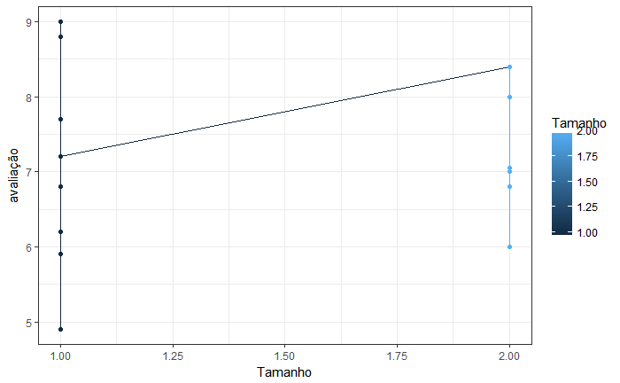

```r
menoresTemporadas10 %>%  ggplot(aes(x = Tamanho, y = avaliação, color=Tamanho)) +
  geom_line() +
  geom_point()
```

Pelos gráficos podemos ver que temporadas bem pequenas tendem a variar muito sua avalição, enquanto temporadas muito grande tem uma variação menor ficando com a nota em médio perto de 7.5.